# Heart Attack

Your Name Here

2023-10-25

# Abstract

The risk of heart disease is a growing concern for cardiovascular health, which claims millions of lives around the world each year. Therefore, how to control the threat of this disease to human health has become a very important issue. Doctors are focused on how to prevent heart attacks in patients at a time when people are curious about a healthier lifestyle for the heart. Therefore, this data analysis report conducted Multilevel regression based on a multiple Logistic regression model to explore the effects of various clinical indicators and lifestyle habits on the risk of heart disease. According to the analysis results, some life suggestions are put forward for people. However, this model is not accurate enough, due to interpretability concerns, and machine learning and deep learning methods are not presented in this report. In the future, we will explore the machine learning model with high interpretability and better fitting prediction effect for further research.

## Keywords:

Multilevel Regression Model, Heart Attack Risk, Health Information.

# Introduction

According to WHO’s 2019 Global Health Estimates Report, heart disease remains the number one killer of deaths from disease and injury in the early 2000s. Every year, millions of people around the world are killed by heart disease, which is a growing threat to people’s health and security. Therefore, it is very important to study the risk of heart disease and people’s clinical indicators and lifestyle habits. Clinicians were curious: How could they tell if a patient was at risk for cardiovascular disease based on cholesterol, Triglycerides and blood pressure? People are also concerned: What kind of routine can protect them from heart disease? Therefore, this data analysis report uses multiple Logistic regression models to explore these issues, hoping to make some contributions to reducing the incidence and mortality of heart disease.

# Data

## Data Collection Process

This is a clinical diagnostic data on heart disease risk collected from 20 countries in the northern and southern hemispheres and continents, including Argentina, Australia, Brazil, Canada, China, Colombia, France, Germany, India, Italy, Japan, NewZealand, Nigeria, SouthAfrica, SouthKorea, Spain, Thailand, UK, Vietnam and USA. The data set includes information on more than 8,000 patients, including their medical tests and lifestyle habits. Multiple Logistic regression models can be used to determine the relationship between heart disease risk and patients’ medical indicators and lifestyle habits.

## Data Summary

```r
data <- read.csv("heart_attack_prediction_dataset.csv")
```

Do the data wrangling firstly. After observation, it can be found that there are many character data in the data set, which needs to be modified column by column. For example, in the gender column, if male is 1 and female is 0, the meaning of this variable in the regression will be expressed as the chance of heart disease caused by gender differences.

```r
data$Sex <- ifelse(data$Sex == "Male", 1, 0)
```

Similarly, modify other columns into a form that could be easily analysed.

```r
data$Blood.Pressure <- as.character(data$Blood.Pressure)
split_values  <- strsplit(data$Blood.Pressure, "/")
data$High.Blood.Pressure <- as.numeric(sapply(split_values, function(x) as.numeric(x[1])))
data$Low.Blood.Pressure <- as.numeric(sapply(split_values, function(x) as.numeric(x[2])))
data <- data[, -which(names(data) == "Blood.Pressure")]

data$Unhealthy.Diet <- ifelse(data$Diet == "Unhealthy", 1, 0)
data$Healthy.Diet <- ifelse(data$Diet == "Healthy", 1, 0)
data <- data[, -which(names(data) == "Diet")]
```

```r
y <- data$Heart.Attack.Risk
```

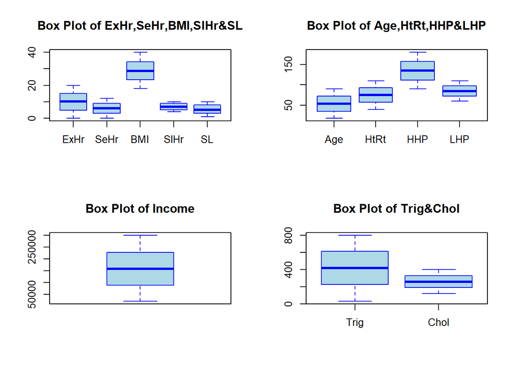

```r
par(mfrow=c(2, 2))
boxplot(data.frame(ExHr = data$Exercise.Hours.Per.Week,
                   SeHr = data$Sedentary.Hours.Per.Day,
                   BMI = data$BMI,
                   SlHr = data$Sleep.Hours.Per.Day,
                   SL = data$Stress.Level
                   ),
        main="Box Plot of ExHr,SeHr,BMI,SlHr&SL", col="lightblue", border="blue", notch=FALSE, horizontal=FALSE)
boxplot(data.frame(Age = data$Age,
                   HtRt = data$Heart.Rate,
                   HHP = data$High.Blood.Pressure,
                   LHP = data$Low.Blood.Pressure
                   ),
        main="Box Plot of Age,HtRt,HHP&LHP", col="lightblue", border="blue", notch=FALSE, horizontal=FALSE)
boxplot(data.frame(Income = data$Income),
        main="Box Plot of Income", col="lightblue", border="blue", notch=FALSE, horizontal=FALSE)
boxplot(data.frame(Trig = data$Triglycerides, Chol = data$Cholesterol),
        main="Box Plot of Trig&Chol", col="lightblue", border="blue", notch=FALSE, horizontal=FALSE)
```

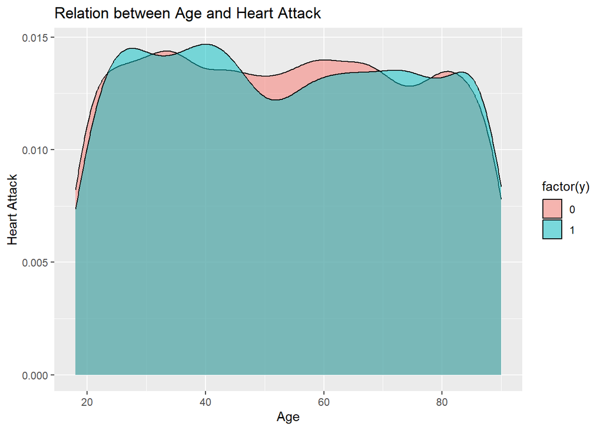

```r
ggplot(data, aes(x = Age, fill = factor(y))) +
  geom_density(alpha = 0.5)+
  labs(title = "Relation between Age and Heart Attack", x = "Age", y = "Heart Attack")
```

From the Relation between Age and Heart Attack, it appears that middle-aged people are less likely to be at risk of heart disease than younger and older people.

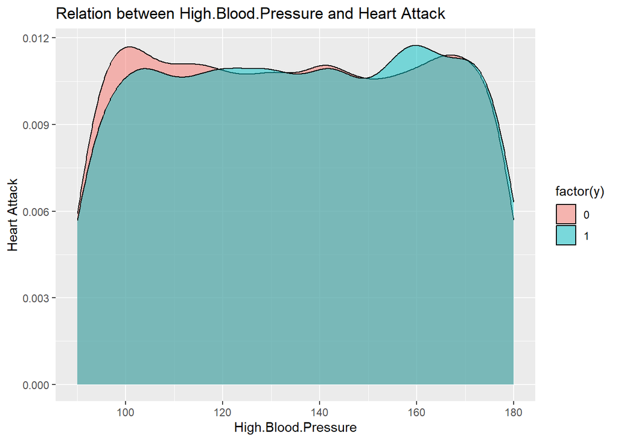

```r
ggplot(data, aes(x = High.Blood.Pressure, fill = factor(y))) +
  geom_density(alpha = 0.5)+
  labs(title = "Relation between High.Blood.Pressure and Heart Attack", x = "High.Blood.Pressure", y = "Heart Attack")
```

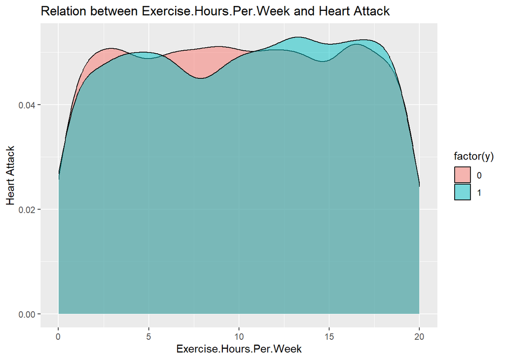

```r
ggplot(data, aes(x = Exercise.Hours.Per.Week, fill = factor(y))) +
  geom_density(alpha = 0.5)+
  labs(title = "Relation between Exercise.Hours.Per.Week and Heart Attack", x = "Exercise.Hours.Per.Week", y = "Heart Attack")
```

It is often said that active exercise contributes to physical and mental health. But from this figure, we found that if the Exercise.Hours.Per..Week is more than 10, it seems to be more likely to cause heart disease.

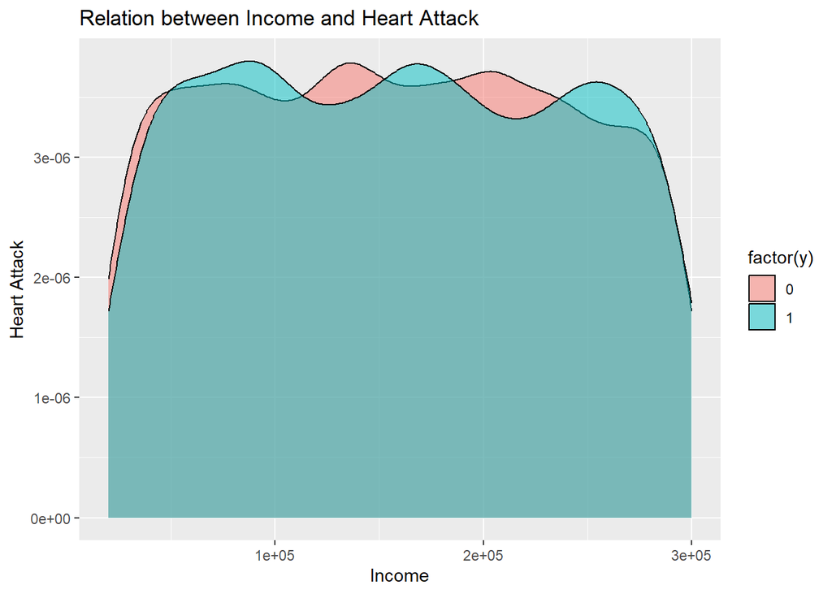

```r
ggplot(data, aes(x = Income, fill = factor(y))) +
  geom_density(alpha = 0.5)+
  labs(title = "Relation between Income and Heart Attack", x = "Income", y = "Heart Attack")
```

There did not appear to be a significant relationship between income and heart disease risk.

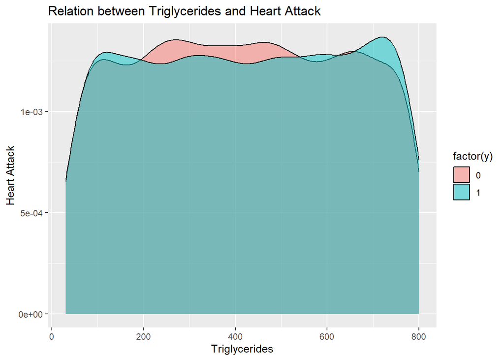

```r
ggplot(data, aes(x = Triglycerides, fill = factor(y))) +
  geom_density(alpha = 0.5)+
  labs(title = "Relation between Triglycerides and Heart Attack", x = "Triglycerides", y = "Heart Attack")
```

According to medical wisdom, high levels of plasma triglycerides can be associated with an increased risk of cardiovascular disease. This picture seems to confirm it.

# Methods

A Multilevel Regression Model is a statistical model used to analyze hierarchical data. It is also known as a Hierarchical Linear Model (HLM), Mixed-Effects Model, or Random Effects Model. This model is suitable for situations where research data contains multiple hierarchies, where observations (individuals, groups, or other units) belong to different groups at different levels and may be influenced by their respective levels.

The basic idea of a multilevel regression model is to consider multiple levels of variability simultaneously when analyzing data. These levels can be formalized by the following formula:

First: Let’s divide the data set into 2 parts by the variable Hemisphere. Namely, a single data point belongs to Northern Hemisphere or Southern Hemisphere and the information of Continent and Country are ignored here. Here Hemisphere of a single data point equals to 1 means the patient lives in Northern Hemisphere. Thus the $\beta$ estimated for it denotes the difference of impact in heart attack between 2 half Hemispheres.

$$Y = BX_1 + \epsilon \quad (1)$$

```r
data$Hemisphere<- ifelse(data$Hemisphere == "Northern Hemisphere", 1, 0)
X_Hemisphere <- data[, -which(names(data) %in%  c("Patient.ID","Country","Continent","Heart.Attack.Risk"))]

model_Hemisphere <- glm(y ~ ., data = cbind(X_Hemisphere,y), family = binomial(link = "logit"))
```

Second: Let’s divide the data set into 6 parts by the variable Continent. Namely, a single data point belongs to its continent and the information of Country are ignored here. One patient is assumed to live in North America by default, so no binary variable for North America is set in $X_2$. Hemisphere remains here for some continents straddle the northern and southern hemispheres.

$$Y = BX_2 + \epsilon \quad (2)$$

```r
data$Africa <- ifelse(data$Continent == "Africa", 1, 0)
data$Asia <- ifelse(data$Continent == "Asia", 1, 0)
data$Australia <- ifelse(data$Continent == "Australia", 1, 0)
data$Europe <- ifelse(data$Continent == "Europe", 1, 0)
data$SouthAmerica <- ifelse(data$Continent == "South America", 1, 0)

X_Continent <- data[, -which(names(data) %in% c("Patient.ID","Country","Continent","Heart.Attack.Risk"))]

model_Continent <- glm(y ~ ., data = cbind(X_Continent,y), family = binomial(link = "logit"))
```

Third: Let’s move the hierarchy down to the national level, where different patients come from different countries. Patients in each country were observed to be from the same hemisphere or continent. This is especially true in countries that straddle the northern and southern hemispheres, such as Colombia and Brazil. So here we delete the two variables of Continent and Hemisphere. And one patient is assumed to live in United States by default, so no binary variable for US is set in $X_3$.
$$Y = BX_3 + \epsilon \quad (3)$$

```r
data$Argentina <- ifelse(data$Country == "Argentina", 1, 0)
data$Australia1 <- ifelse(data$Country == "Australia", 1, 0)
data$Brazil <- ifelse(data$Country == "Brazil", 1, 0)
data$Canada <- ifelse(data$Country == "Canada", 1, 0)
data$China <- ifelse(data$Country == "China", 1, 0)
data$Colombia <- ifelse(data$Country == "Colombia", 1, 0)
data$France <- ifelse(data$Country == "France", 1, 0)
data$Germany <- ifelse(data$Country == "Germany", 1, 0)
data$India <- ifelse(data$Country == "India", 1, 0)
data$Italy <- ifelse(data$Country == "Italy", 1, 0)
data$Japan <- ifelse(data$Country == "Japan", 1, 0)
data$NewZealand <- ifelse(data$Country == "New Zealand", 1, 0)
data$Nigeria <- ifelse(data$Country == "Nigeria", 1, 0)
data$SouthAfrica <- ifelse(data$Country == "South Africa", 1, 0)
data$SouthKorea <- ifelse(data$Country == "South Korea", 1, 0)
data$Spain <- ifelse(data$Country == "Spain", 1, 0)
data$Thailand <- ifelse(data$Country == "Thailand", 1, 0)
data$UK <- ifelse(data$Country == "United Kingdom", 1, 0)
data$Vietnam <- ifelse(data$Country == "Vietnam", 1, 0)

X_Country <- data[, -which(names(data) %in%  c("Patient.ID","Country","Continent","Heart.Attack.Risk",
                    "Africa","Asia","Australia","Europe","SouthAmerica",
                    "Hemisphere"))]

model_Country <- glm(y ~ ., data = cbind(X_Country,y), family = binomial(link = "logit"))
```

# Results

After constructing the three multiple logistic regression models, the summary() function is used to obtain the model results. Through observation and analysis, it is found that it is difficult to get accurate fitting because of the quality of variables. Some machine learning methods, such as random forest algorithms and support vector machine algorithms, have also been tried, but the results are not good enough. The final choice is to present only the results of multiple regression analysis and conduct the appropriate analysis.

```r
summary(model_Hemisphere)
```

```
##
## Call:
## glm(formula = y ~ ., family = binomial(link = "logit"), data = cbind(X_Hemisphere,
##     y))
##
## Deviance Residuals:
##     Min       1Q   Median       3Q      Max
## -1.0962  -0.9523  -0.9079   1.4059   1.5819
##
## Coefficients:
##                                   Estimate Std. Error z value Pr(>|z|)
## (Intercept)                     -7.685e-01  2.815e-01  -2.730  0.00633 **
## Age                              1.174e-03  1.176e-03   0.998  0.31807
## Sex                              4.406e-02  5.842e-02   0.754  0.45073
## Cholesterol                      5.010e-04  2.765e-04   1.812  0.07003 .
## Heart.Rate                      -4.569e-04  1.087e-03  -0.421  0.67411
## Diabetes                         7.827e-02  4.703e-02   1.664  0.09610 .
## Family.History                  -2.770e-03  4.468e-02  -0.062  0.95056
## Smoking                         -9.477e-02  9.579e-02  -0.989  0.32248
## Obesity                         -5.706e-02  4.467e-02  -1.277  0.20148
## Alcohol.Consumption             -6.027e-02  4.549e-02  -1.325  0.18519
## Exercise.Hours.Per.Week          3.988e-03  3.861e-03   1.033  0.30158
## Previous.Heart.Problems          4.774e-03  4.467e-02   0.107  0.91488
## Medication.Use                   1.064e-02  4.467e-02   0.238  0.81166
## Stress.Level                    -3.205e-03  7.817e-03  -0.410  0.68177
## Sedentary.Hours.Per.Day         -3.849e-03  6.442e-03  -0.598  0.55013
## Income                           2.410e-07  2.771e-07   0.870  0.38452
## BMI                             -1.426e-04  3.534e-03  -0.040  0.96781
## Triglycerides                    8.971e-05  9.983e-05   0.899  0.36887
## Physical.Activity.Days.Per.Week -4.398e-03  9.782e-03  -0.450  0.65298
## Sleep.Hours.Per.Day             -1.876e-02  1.124e-02  -1.669  0.09502 .
## Hemisphere                       5.487e-02  4.680e-02   1.172  0.24108
## High.Blood.Pressure              1.490e-03  8.474e-04   1.758  0.07877 .
## Low.Blood.Pressure              -1.171e-03  1.522e-03  -0.769  0.44178
## Unhealthy.Diet                   2.321e-02  5.499e-02   0.422  0.67297
## Healthy.Diet                     5.331e-02  5.455e-02   0.977  0.32842
## ---
## Signif. codes:  0 '***' 0.001 '**' 0.01 '*' 0.05 '.' 0.1 ' ' 1
##
## (Dispersion parameter for binomial family taken to be 1)
##
##     Null deviance: 11434  on 8762  degrees of freedom
## Residual deviance: 11410  on 8738  degrees of freedom
## AIC: 11460
##
## Number of Fisher Scoring iterations: 4
```

```r
summary(model_Continent)
```

```
##
## Call:
## glm(formula = y ~ ., family = binomial(link = "logit"), data = cbind(X_Continent,
##     y))
##
## Deviance Residuals:
##     Min       1Q   Median       3Q      Max
## -1.1066  -0.9520  -0.9041   1.4028   1.6183
##
## Coefficients:
##                                   Estimate Std. Error z value Pr(>|z|)
## (Intercept)                     -7.716e-01  2.956e-01  -2.610  0.00904 **
## Age                              1.132e-03  1.177e-03   0.962  0.33625
## Sex                              4.199e-02  5.847e-02   0.718  0.47262
## Cholesterol                      5.005e-04  2.767e-04   1.809  0.07046 .
## Heart.Rate                      -4.945e-04  1.087e-03  -0.455  0.64923
## Diabetes                         8.063e-02  4.707e-02   1.713  0.08673 .
## Family.History                  -4.333e-03  4.471e-02  -0.097  0.92281
## Smoking                         -9.039e-02  9.587e-02  -0.943  0.34572
## Obesity                         -5.800e-02  4.469e-02  -1.298  0.19431
## Alcohol.Consumption             -6.023e-02  4.552e-02  -1.323  0.18575
## Exercise.Hours.Per.Week          3.960e-03  3.863e-03   1.025  0.30534
## Previous.Heart.Problems          3.164e-03  4.471e-02   0.071  0.94357
## Medication.Use                   1.262e-02  4.470e-02   0.282  0.77760
## Stress.Level                    -3.579e-03  7.822e-03  -0.458  0.64727
## Sedentary.Hours.Per.Day         -4.109e-03  6.450e-03  -0.637  0.52413
## Income                           2.408e-07  2.772e-07   0.869  0.38498
## BMI                             -2.064e-04  3.535e-03  -0.058  0.95344
## Triglycerides                    9.022e-05  9.987e-05   0.903  0.36628
## Physical.Activity.Days.Per.Week -4.086e-03  9.787e-03  -0.417  0.67635
## Sleep.Hours.Per.Day             -1.924e-02  1.125e-02  -1.711  0.08707 .
## Hemisphere                       1.259e-01  6.489e-02   1.941  0.05229 .
## High.Blood.Pressure              1.482e-03  8.478e-04   1.748  0.08048 .
## Low.Blood.Pressure              -1.167e-03  1.523e-03  -0.766  0.44348
## Unhealthy.Diet                   2.395e-02  5.504e-02   0.435  0.66348
## Healthy.Diet                     5.425e-02  5.461e-02   0.993  0.32050
## Africa                           3.265e-02  1.043e-01   0.313  0.75438
## Asia                            -9.618e-02  8.187e-02  -1.175  0.24007
## Australia                        6.584e-02  1.188e-01   0.554  0.57949
## Europe                          -8.572e-02  8.693e-02  -0.986  0.32410
## SouthAmerica                     4.428e-02  1.005e-01   0.441  0.65949
## ---
## Signif. codes:  0 '***' 0.001 '**' 0.01 '*' 0.05 '.' 0.1 ' ' 1
##
## (Dispersion parameter for binomial family taken to be 1)
##
##     Null deviance: 11434  on 8762  degrees of freedom
## Residual deviance: 11404  on 8733  degrees of freedom
## AIC: 11464
##
## Number of Fisher Scoring iterations: 4
```

However, people on other continents are not significantly more exposed to heart disease than North Americans, according to model_Continent’s summary report.

```r
summary(model_Country)
```

```
##
## Call:
## glm(formula = y ~ ., family = binomial(link = "logit"), data = cbind(X_Country,
##     y))
##
## Deviance Residuals:
##     Min       1Q   Median       3Q      Max
## -1.1297  -0.9543  -0.8951   1.3928   1.6385
##
## Coefficients:
##                                   Estimate Std. Error z value Pr(>|z|)
## (Intercept)                     -5.740e-01  2.985e-01  -1.923   0.0545 .
## Age                              1.132e-03  1.179e-03   0.960   0.3371
## Sex                              4.326e-02  5.855e-02   0.739   0.4600
## Cholesterol                      4.839e-04  2.770e-04   1.747   0.0807 .
## Heart.Rate                      -4.591e-04  1.089e-03  -0.422   0.6732
## Diabetes                         8.057e-02  4.713e-02   1.710   0.0873 .
## Family.History                  -7.844e-03  4.478e-02  -0.175   0.8609
## Smoking                         -8.983e-02  9.598e-02  -0.936   0.3493
## Obesity                         -5.756e-02  4.474e-02  -1.287   0.1982
## Alcohol.Consumption             -5.974e-02  4.559e-02  -1.310   0.1901
## Exercise.Hours.Per.Week          4.106e-03  3.868e-03   1.062   0.2884
## Previous.Heart.Problems          5.329e-03  4.479e-02   0.119   0.9053
## Medication.Use                   1.249e-02  4.476e-02   0.279   0.7801
## Stress.Level                    -3.942e-03  7.836e-03  -0.503   0.6149
## Sedentary.Hours.Per.Day         -4.204e-03  6.458e-03  -0.651   0.5151
## Income                           2.551e-07  2.776e-07   0.919   0.3582
## BMI                             -4.532e-04  3.540e-03  -0.128   0.8981
## Triglycerides                    8.317e-05  1.000e-04   0.831   0.4057
## Physical.Activity.Days.Per.Week -3.644e-03  9.804e-03  -0.372   0.7101
## Sleep.Hours.Per.Day             -1.947e-02  1.126e-02  -1.729   0.0838 .
## High.Blood.Pressure              1.506e-03  8.492e-04   1.774   0.0761 .
## Low.Blood.Pressure              -1.114e-03  1.525e-03  -0.730   0.4652
## Unhealthy.Diet                   2.904e-02  5.512e-02   0.527   0.5983
## Healthy.Diet                     5.876e-02  5.470e-02   1.074   0.2827
## Argentina                       -1.005e-01  1.385e-01  -0.726   0.4680
## Australia1                      -7.542e-02  1.399e-01  -0.539   0.5899
## Brazil                          -1.752e-01  1.399e-01  -1.253   0.2103
## Canada                          -1.439e-01  1.412e-01  -1.019   0.3082
## China                           -1.626e-01  1.417e-01  -1.148   0.2511
```

[output cut: 9 more lines]

```
## SouthKorea                       2.985e-02  1.424e-01   0.210   0.8340
## Spain                           -1.941e-01  1.425e-01  -1.362   0.1732
## Thailand                        -7.727e-02  1.414e-01  -0.546   0.5848
## UK                              -1.823e-01  1.403e-01  -1.299   0.1939
## Vietnam                         -1.972e-01  1.429e-01  -1.380   0.1676
## ---
## Signif. codes:  0 '***' 0.001 '**' 0.01 '*' 0.05 '.' 0.1 ' ' 1
##
## (Dispersion parameter for binomial family taken to be 1)
##
##     Null deviance: 11434  on 8762  degrees of freedom
## Residual deviance: 11391  on 8720  degrees of freedom
## AIC: 11477
##
## Number of Fisher Scoring iterations: 4
```

Interestingly, from the summary report of model_Country, it can be seen that Indians, Italians and Japanese are significantly less likely to get heart disease than Americans, and the two variables of India and Italy are very significant, which may be due to the different genetic genes and living habits of people in different countries. Moreover, regression parameters for most other countries are negative, and positive regression parameters (such as Nigeria and South Korea) are very insignificant, which may indicate that the United States, Nigeria and South Korea are the countries with the highest incidence of heart disease among these countries.

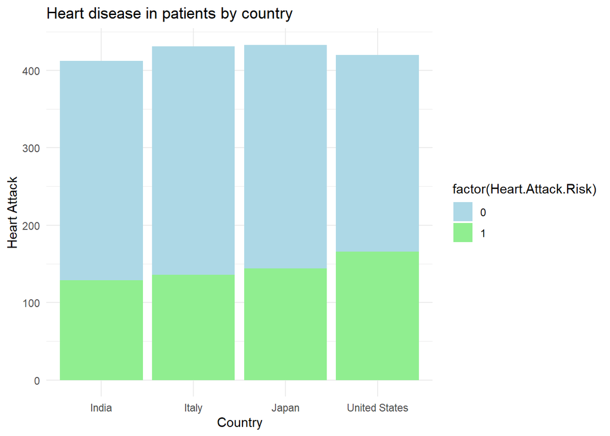

```r
selected_countries <- c("Japan", "Italy", "India", "United States")
subset_data <- data[data$Country %in% selected_countries,]

ggplot(subset_data, aes(x = Country, fill = factor(Heart.Attack.Risk))) +
  geom_bar() +
  labs(title = "Heart disease in patients by country", x = "Country", y = "Heart Attack") +
  scale_fill_manual(values = c("0" = "light blue", "1" = "light green")) +
  theme_minimal()
```

# Conclusions

To sum up, this data analysis report draws the following conclusions and puts forward some relevant recommendations.

## Weaknesses

The sample size of the data is sufficient, but it does not fully reveal the impact of clinical indicators and lifestyle habits on heart disease risk. If you use dimensionality reduction methods such as PCA, or machine learning and deep learning methods, you can indeed get better accuracy for prediction, but these methods lack interpretability, so it is difficult to make recommendations for clinicians’ diagnoses and people’s lifestyle habits. Perhaps some more advanced interpretable machine learning methods can be applied to this dataset to get more accurate advice and help.